# Linear modeling and its assumptions

Fundamental Techniques in Data Science with R

## Last week

A review of last week’s contents

## Today

- the linear model
- assumptions associated with the linear model

## We use the following packages

```r
library(MASS)
library(dplyr)
library(magrittr)
library(ggplot2)
library(mice)
library(DAAG)
library(car)
```

## Statistical models

## Statistical model

The mathematical formulation of relationship between variables can be written as

\[ \mbox{observed}=\mbox{predicted}+\mbox{error} \]

or (for the greek people) in notation as \[y=\mu+\varepsilon\]

where

- \(\mu\) (mean) is the part of \(Y\) that is explained by model
- \(\varepsilon\) (residual) is the part of \(Y\) that is not explained by model

## A simple example

Regression model:

- Model individual age from weight

\[ \text{age}_i=\alpha+\beta\cdot{\text{weight}}_i+\varepsilon_i \]

where

- \(\alpha+\beta{x}_i\) is the mean of `age`, \(y\), conditional on `weight`, \(x\).
- \(\varepsilon_i\) is random variation

## The linear model

The function `lm()` is a base function in `R` and allows you to pose a variety of linear models.

```r
args(lm)
```

```
## function (formula, data, subset, weights, na.action, method = "qr",
##     model = TRUE, x = FALSE, y = FALSE, qr = TRUE, singular.ok = TRUE,
##     contrasts = NULL, offset, ...)
## NULL
```

If we want to know what these arguments do we can ask R:

```r
?lm
```

This will open a help page on the `lm()` function.

## Continuous predictors

To obtain a linear model with a main effects for `wgt`, we formulate \(age\sim wgt\)

```r
library(mice)
fit <- with(boys, lm(age ~ wgt))
fit
```

```
##
## Call:
## lm(formula = age ~ wgt)
##
## Coefficients:
## (Intercept)          wgt
##     -0.1924       0.2517
```

## Continuous predictors: more detail

```r
summary(fit)
```

```
##
## Call:
## lm(formula = age ~ wgt)
##
## Residuals:
##      Min       1Q   Median       3Q      Max
## -12.0907  -1.1686  -0.5342   1.4286   5.5143
##
## Coefficients:
##              Estimate Std. Error t value Pr(>|t|)
## (Intercept) -0.192377   0.136878  -1.405     0.16
## wgt          0.251673   0.003018  83.395   <2e-16 ***
## ---
## Signif. codes:  0 '***' 0.001 '**' 0.01 '*' 0.05 '.' 0.1 ' ' 1
##
## Residual standard error: 2.142 on 742 degrees of freedom
##   (4 observations deleted due to missingness)
## Multiple R-squared:  0.9036, Adjusted R-squared:  0.9035
## F-statistic:  6955 on 1 and 742 DF,  p-value: < 2.2e-16
```

## Continuous predictors

To obtain a linear model with just main effects for `wgt` and `hgt`, we formulate \(age\sim wgt + hgt\)

```r
require(mice)
fit <- with(boys, lm(age ~ wgt + hgt))
fit
```

```
##
## Call:
## lm(formula = age ~ wgt + hgt)
##
## Coefficients:
## (Intercept)          wgt          hgt
##    -7.45952      0.07138      0.10660
```

## Continuous predictors: more detail

```r
summary(fit)
```

```
##
## Call:
## lm(formula = age ~ wgt + hgt)
##
## Residuals:
##     Min      1Q  Median      3Q     Max
## -5.1627 -0.8836 -0.1656  0.8765  4.4365
##
## Coefficients:
##              Estimate Std. Error t value Pr(>|t|)
## (Intercept) -7.459525   0.246782  -30.23   <2e-16 ***
## wgt          0.071376   0.005949   12.00   <2e-16 ***
## hgt          0.106602   0.003336   31.96   <2e-16 ***
## ---
## Signif. codes:  0 '***' 0.001 '**' 0.01 '*' 0.05 '.' 0.1 ' ' 1
##
## Residual standard error: 1.391 on 724 degrees of freedom
##   (21 observations deleted due to missingness)
## Multiple R-squared:  0.9592, Adjusted R-squared:  0.9591
## F-statistic:  8510 on 2 and 724 DF,  p-value: < 2.2e-16
```

## Continuous predictors: interaction effects

To predict \(age\) from \(wgt\), \(hgt\) and the interaction \(wgt*hgt\) we formulate \(age\sim wgt * hgt\)

```r
fit <- with(boys, lm(age ~ wgt * hgt))
fit
```

```
##
## Call:
## lm(formula = age ~ wgt * hgt)
##
## Coefficients:
## (Intercept)          wgt          hgt      wgt:hgt
##  -7.2833480   -0.0196161    0.1120325    0.0004142
```

## and with more detail

```r
summary(fit)
```

```
##
## Call:
## lm(formula = age ~ wgt * hgt)
##
## Residuals:
##     Min      1Q  Median      3Q     Max
## -5.2067 -0.8603 -0.1419  0.8452  4.7526
##
## Coefficients:
##               Estimate Std. Error t value Pr(>|t|)
## (Intercept) -7.2833480  0.2510218 -29.015  < 2e-16 ***
## wgt         -0.0196161  0.0284921  -0.688  0.49137
## hgt          0.1120325  0.0037076  30.217  < 2e-16 ***
## wgt:hgt      0.0004142  0.0001269   3.265  0.00115 **
## ---
## Signif. codes:  0 '***' 0.001 '**' 0.01 '*' 0.05 '.' 0.1 ' ' 1
##
## Residual standard error: 1.382 on 723 degrees of freedom
##   (21 observations deleted due to missingness)
## Multiple R-squared:  0.9598, Adjusted R-squared:  0.9596
## F-statistic:  5752 on 3 and 723 DF,  p-value: < 2.2e-16
```

## Categorical predictors in the linear model

If a categorical variable is entered into function `lm()`, it is automatically converted to a dummy set in `R`. The first level is always taken as the reference category. If we want another reference category we can use the function `relevel()` to change this.

```r
fit <- with(boys, lm(age ~ reg))
```

## and again with more detail

```r
summary(fit)
```

```
##
## Call:
## lm(formula = age ~ reg)
##
## Residuals:
##     Min      1Q  Median      3Q     Max
## -11.805  -7.376   1.339   5.955  11.935
##
## Coefficients:
##             Estimate Std. Error t value Pr(>|t|)
## (Intercept)  11.8984     0.7595  15.666  < 2e-16 ***
## regeast      -2.6568     0.9312  -2.853 0.004449 **
## regwest      -2.9008     0.8788  -3.301 0.001011 **
## regsouth     -3.3074     0.9064  -3.649 0.000282 ***
## regcity      -3.6266     1.1031  -3.288 0.001058 **
## ---
## Signif. codes:  0 '***' 0.001 '**' 0.01 '*' 0.05 '.' 0.1 ' ' 1
##
## Residual standard error: 6.836 on 740 degrees of freedom
##   (3 observations deleted due to missingness)
## Multiple R-squared:  0.02077,    Adjusted R-squared:  0.01548
## F-statistic: 3.925 on 4 and 740 DF,  p-value: 0.003678
```

## Components of the linear model

```r
names(fit) # the names of the list with output objects
```

```
##  [1] "coefficients"  "residuals"     "effects"       "rank"
##  [5] "fitted.values" "assign"        "qr"            "df.residual"
##  [9] "na.action"     "contrasts"     "xlevels"       "call"
## [13] "terms"         "model"
```

```r
fit$coef  # show the estimated coefficients
```

```
## (Intercept)     regeast     regwest    regsouth     regcity
##   11.898420   -2.656786   -2.900792   -3.307388   -3.626625
```

```r
coef(fit) # alternative
```

```
## (Intercept)     regeast     regwest    regsouth     regcity
##   11.898420   -2.656786   -2.900792   -3.307388   -3.626625
```

## Fitting a line to data

## Linear regression

Linear regression model \[ y_i=\alpha+\beta{x}_i+\varepsilon_i \]

Assumptions:

- \(y_i\) conditionally normal with mean \(\mu_i=\alpha+\beta{x}_i\)
- \(\varepsilon_i\) are \(i.i.d.\) with mean 0 and (constant) variance \(\sigma^2\)

## The `anscombe` data

```r
head(anscombe)
```

```
##   x1 x2 x3 x4   y1   y2    y3   y4
## 1 10 10 10  8 8.04 9.14  7.46 6.58
## 2  8  8  8  8 6.95 8.14  6.77 5.76
## 3 13 13 13  8 7.58 8.74 12.74 7.71
## 4  9  9  9  8 8.81 8.77  7.11 8.84
## 5 11 11 11  8 8.33 9.26  7.81 8.47
## 6 14 14 14  8 9.96 8.10  8.84 7.04
```

Or, alternatively,

```r
anscombe %>%
  head
```

```
##   x1 x2 x3 x4   y1   y2    y3   y4
## 1 10 10 10  8 8.04 9.14  7.46 6.58
## 2  8  8  8  8 6.95 8.14  6.77 5.76
## 3 13 13 13  8 7.58 8.74 12.74 7.71
## 4  9  9  9  8 8.81 8.77  7.11 8.84
## 5 11 11 11  8 8.33 9.26  7.81 8.47
## 6 14 14 14  8 9.96 8.10  8.84 7.04
```

## Fitting a line

```r
anscombe %>%
  ggplot(aes(y1, x1)) +
  geom_point() +
  geom_smooth(method = "lm")
```

## Fitting a line

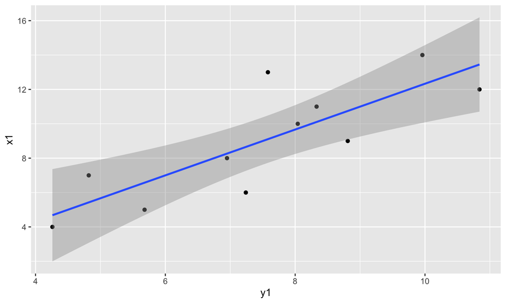

## Fitting a line

The linear model would take the following form:

```r
fit <-
  yourdata %>%
  lm(youroutcome ~ yourpredictors)

summary(fit)
```

Output:

- Residuals: minimum, maximum and quartiles
- Coefficients: estimates, SE’s, t-values and \(p\)-values
- Fit measures
  - Residuals SE (standard error residuals)
  - Multiple R-squared (proportion variance explained)
  - F-statistic and \(p\)-value (significance test model)

## `anscombe` example

```r
fit <- anscombe %$%
  lm(y1 ~ x1)

summary(fit)
```

```
##
## Call:
## lm(formula = y1 ~ x1)
##
## Residuals:
##      Min       1Q   Median       3Q      Max
## -1.92127 -0.45577 -0.04136  0.70941  1.83882
##
## Coefficients:
##             Estimate Std. Error t value Pr(>|t|)
## (Intercept)   3.0001     1.1247   2.667  0.02573 *
## x1            0.5001     0.1179   4.241  0.00217 **
## ---
## Signif. codes:  0 '***' 0.001 '**' 0.01 '*' 0.05 '.' 0.1 ' ' 1
##
## Residual standard error: 1.237 on 9 degrees of freedom
## Multiple R-squared:  0.6665, Adjusted R-squared:  0.6295
## F-statistic: 17.99 on 1 and 9 DF,  p-value: 0.00217
```

## Checking assumptions

1. linearity
   - scatterplot \(y\) and \(x\)
   - include loess curve when in doubt
   - does a squared term improve fit?
2. normality residuals
   - normal probability plots `qqnorm()`
   - if sample is small; `qqnorm` with simulated errors cf. `rnorm(n, 0, s)`
3. constant error variance
   - residual plot
   - scale-location plot

## Linearity

```r
anscombe %>%
  ggplot(aes(x1, y1)) +
  geom_point() +
  geom_smooth(method = "loess", col = "blue") +
  geom_smooth(method = "lm", col = "orange")
```

## Linearity

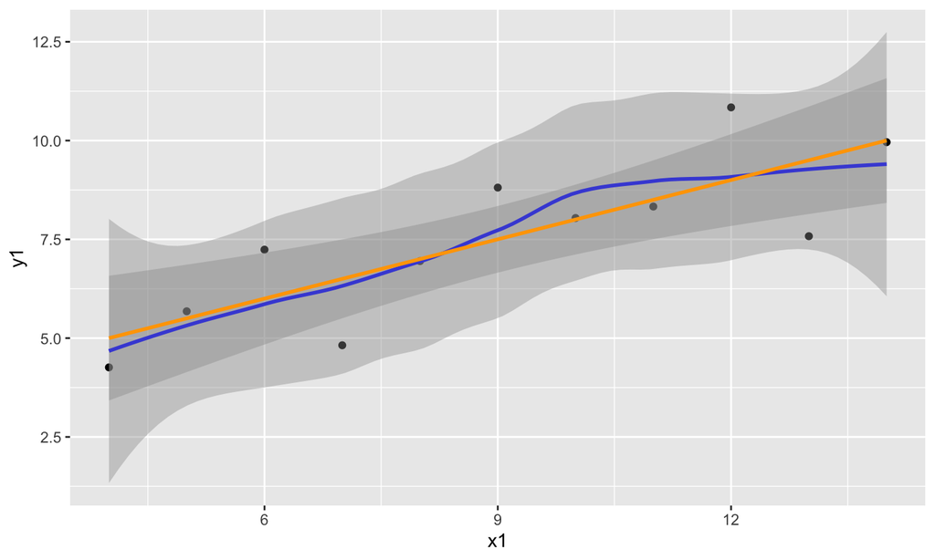

The loess curve suggests slight non-linearity

## Adding a squared term

```r
anscombe %$%
  lm(y1 ~ x1 + I(x1^2)) %>%
  summary()
```

```
##
## Call:
## lm(formula = y1 ~ x1 + I(x1^2))
##
## Residuals:
##     Min      1Q  Median      3Q     Max
## -1.8704 -0.3481 -0.2456  0.7129  1.8072
##
## Coefficients:
##             Estimate Std. Error t value Pr(>|t|)
## (Intercept)  0.75507    3.28815   0.230    0.824
## x1           1.06925    0.78982   1.354    0.213
## I(x1^2)     -0.03162    0.04336  -0.729    0.487
##
## Residual standard error: 1.27 on 8 degrees of freedom
## Multiple R-squared:  0.6873, Adjusted R-squared:  0.6092
## F-statistic: 8.793 on 2 and 8 DF,  p-value: 0.009558
```

## Constant error variance?

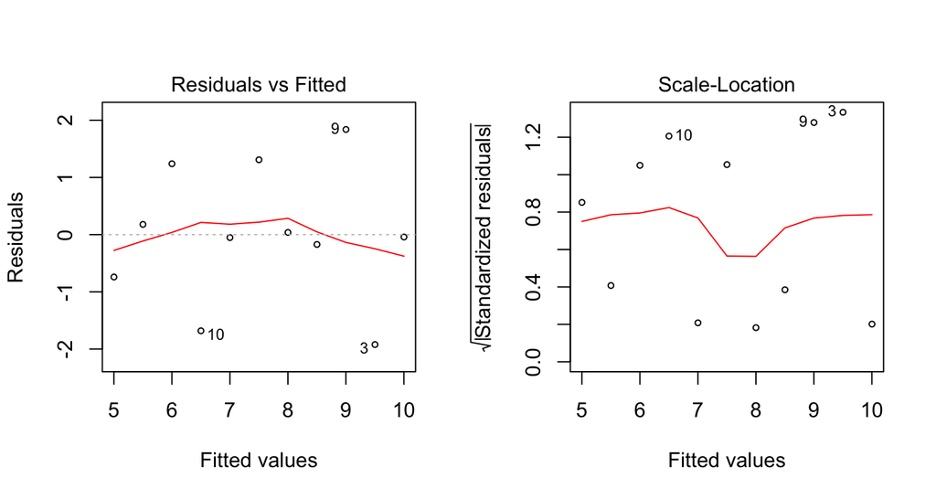

```r
par(mfrow = c(1, 2))
fit %>%
  plot(which = c(1, 3), cex = .6)
```

## No constant error variance!

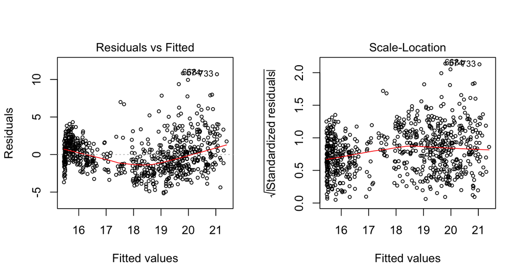

```r
par(mfrow = c(1, 2))
boys %$%
  lm(bmi ~ age) %>%
  plot(which = c(1, 3), cex = .6)
```

## Normality of errors

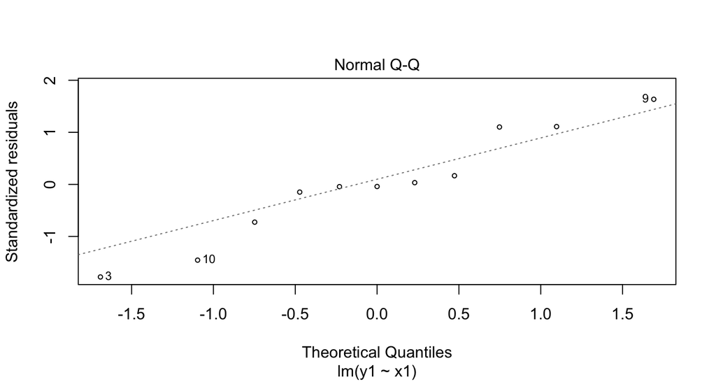

```r
fit %>%
  plot(which = 2, cex = .6)
```

The QQplot shows some divergence from normality at the tails

## Outliers, influence and robust regression

## Outliers and influential cases

Leverage: see the fit line as a lever.

- some points pull/push harder; they have more leverage

Standardized residuals:

- The values that have more leverage tend to be closer to the line
- The line is fit so as to be closer to them
- The residual standard deviation can differ at different points on \(X\) - even if the error standard deviation is constant.
- Therefore we standardize the residuals so that they have constant variance (assuming homoscedasticity).

Cook’s distance: how far the predicted values would move if your model were fit without the data point in question.

- it is a function of the leverage and standardized residual associated with each data point

## Fine

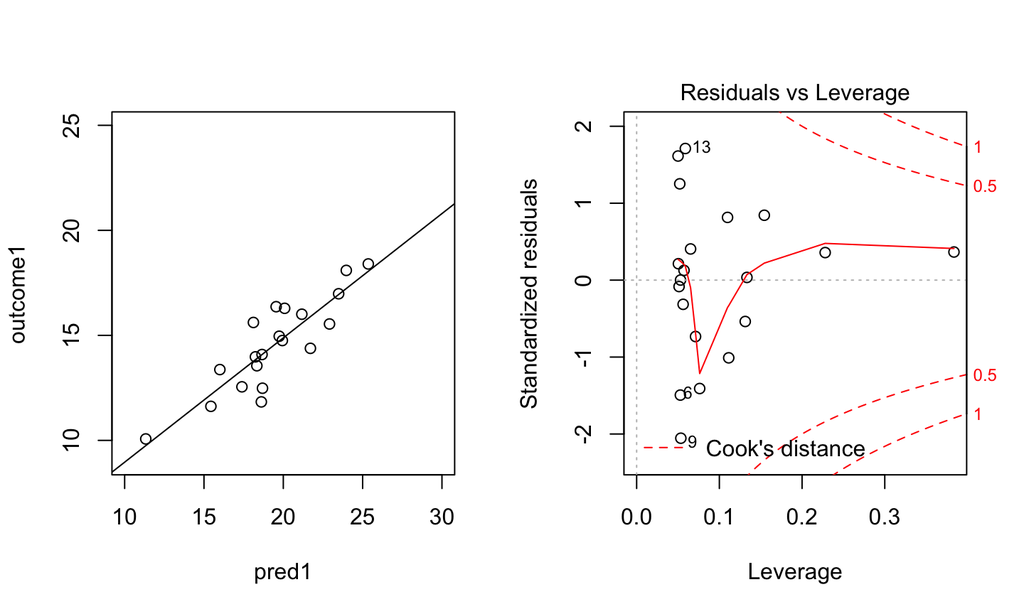

## High leverage, low residual

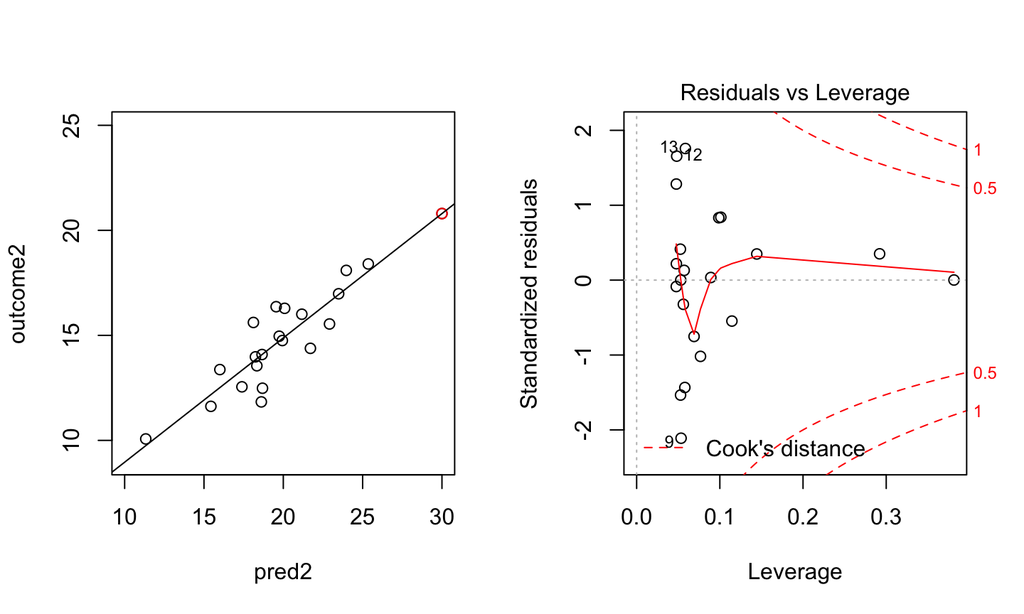

## Low leverage, high residual

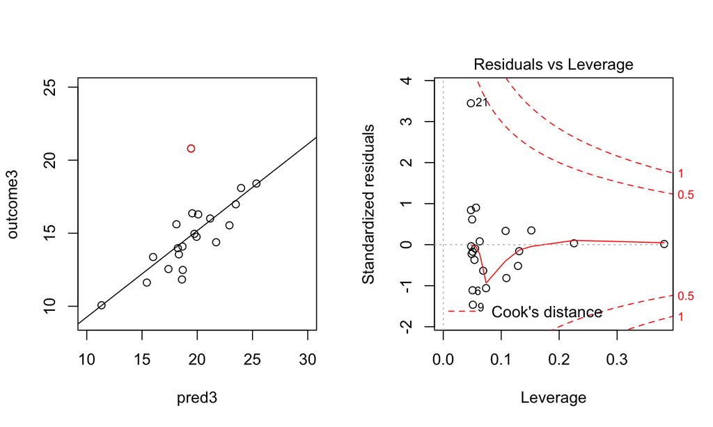

## High leverage, high residual

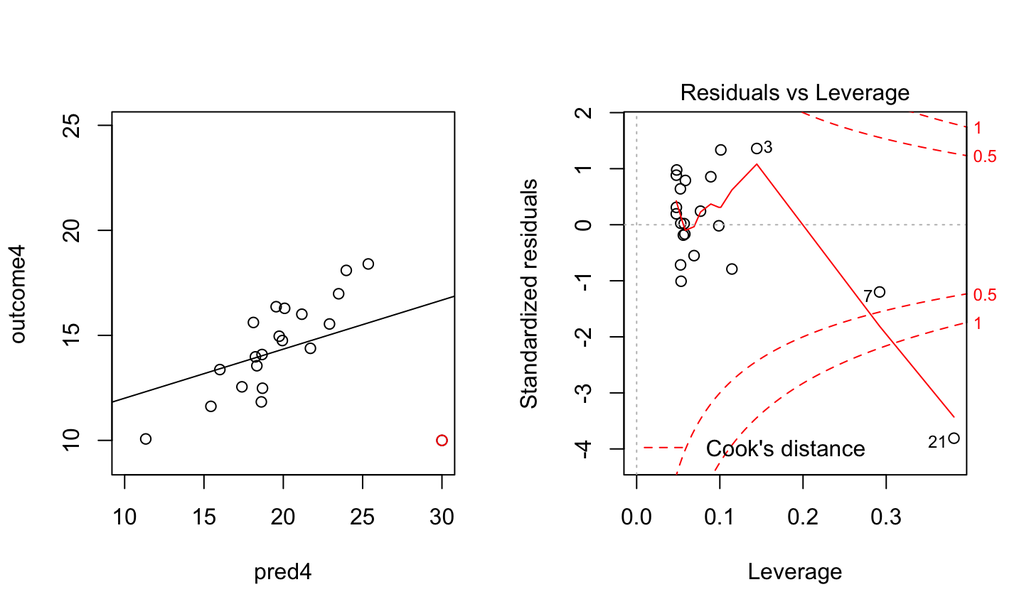

## Outliers and influential cases

Outliers are cases with large \(e_z\) (standardized residuals).

If the model is *correct* we expect:

- 5% of \(|e_z|>1.96\)
- 1% of \(|e_z|>2.58\)
- 0% of \(|e_z|>3.3\)

Influential cases are cases with large influence on parameter estimates

- cases with Cook’s Distance \(> 1\), or
- cases with Cook’s Distance much larger than the rest

## Outliers and influential cases

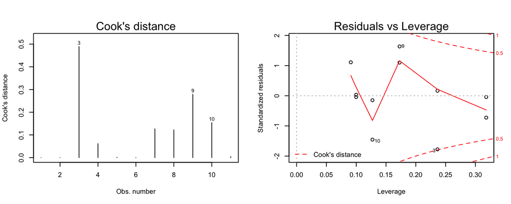

```r
par(mfrow = c(1, 2), cex = .6)
fit %>% plot(which = c(4, 5))
```

There are no cases with \(|e_z|>2\), so no outliers (right plot). There are no cases with Cook’s Distance \(>1\), but case 3 stands out